# Regresja liniowa — analiza zależności ceny samochodu od parametrów technicznych

- Pokaż cały kod
- Ukryj cały kod
- Pokaż źródło

Raport zaliczeniowy ze statystyki stosowanej · zbiór Cars93

Analiza 93 modeli samochodów: cel badania, dane, regresja liniowa, walidacja, diagnostyka i wnioski.

Autor

Marcin Górski

Opublikowano

24 listopada 2026

## Wprowadzenie

Cena samochodu jest związana z jego konstrukcją, osiągami, wyposażeniem i pozycjonowaniem rynkowym. Z punktu widzenia analizy danych interesujące jest ustalenie, ile informacji o zróżnicowaniu cen zawierają łatwo dostępne parametry techniczne. W raporcie badamy związek ceny z mocą silnika, masą pojazdu oraz pochodzeniem producenta.

Analizę przeprowadzono na historycznym zbiorze **Cars93**, zawierającym dane o 93 modelach nowych samochodów oferowanych w USA w 1993 r. Źródłem opisu danych jest publikacja Lock (1993). Zastosowano regresję liniową, porównano cztery modele i sprawdzono ich zachowanie na obserwacjach niewykorzystanych do estymacji.

**AdnotacjaCo będzie wynikiem tej analizy?**

Wyniki pozwolą określić kierunek i wielkość warunkowych związków parametrów z ceną, ocenić niepewność oszacowań oraz oszacować błędy prognoz. Analiza dotyczy historycznej próby modeli aut i nie służy do wyceny współczesnego samochodu.

## Formułowanie celu i problemów badawczych

### Cel badawczy

**Celem badania jest ocena związku mocy silnika, masy pojazdu i pochodzenia producenta z ceną samochodu oraz sprawdzenie, czy uwzględnienie krzywizny zależności poprawia opis danych i prognozowanie.**

### Zmienna objaśniana i zmienne objaśniające

Zmienną objaśnianą jest `Price` — cena w tysiącach USD, zdefiniowana jako średnia ceny wersji podstawowej i najdroższej wersji danego modelu. Nie jest to zaobserwowana cena indywidualnej transakcji.

Wybrane zmienne objaśniające to:

- `Horsepower` — maksymalna moc silnika, w HP;
- `Weight` — masa samochodu, w danych źródłowych w funtach, w raporcie przeliczona na kilogramy;
- `Origin` — pochodzenie producenta: USA albo spoza USA; kategorią odniesienia jest USA.

Modelujemy **logarytm naturalny ceny**. Dzięki temu efekty można interpretować jako względne różnice cen. Składniki kwadratowe mocy i masy dopuszczają zmianę siły związku w różnych częściach zakresu danych.

### Problemy badawcze

1. Jak cena samochodu jest związana z mocą silnika i masą pojazdu?
2. Czy po uwzględnieniu tych parametrów występuje różnica cen między producentami z USA i spoza USA?
3. Czy rozszerzenie modelu o składniki kwadratowe poprawia dopasowanie?
4. Jak duże są błędy prognoz cen w walidacji krzyżowej?
5. Czy diagnostyka wskazuje na istotne ograniczenia przyjętego modelu?

### Jednostka obserwacji

Jedną obserwacją jest **jeden model samochodu**, a nie pojedynczy egzemplarz ani jego właściciel. Wszystkie analizowane zmienne dotyczą tego samego modelu auta.

## Metodyka

### Dlaczego regresja liniowa?

Zmienna zależna jest dodatnią wielkością liczbową. Regresja liniowa umożliwia opisanie jej warunkowego związku z kilkoma predyktorami oraz wyznaczenie przedziałów ufności. Pozwala również uwzględnić zmienną jakościową i składniki wielomianowe. Założenia i interpretację tej metody omawiają Schneider et al. (2010).

Logarytmowanie ceny uzasadniają interpretacja procentowa i prawostronna asymetria cen. Nie gwarantuje ono poprawności modelu: postać zależności i właściwości reszt podlegają osobnej diagnostyce. Dodatkowo porównujemy błędy z modelem ceny bez logarytmowania.

### Idea modelu

Oznaczmy cenę w tysiącach USD przez $P_i$. Zmienne przeskalowano i wycentrowano:

$$x_i = \frac{\operatorname{moc}_i-150}{10}, \qquad
z_i = \frac{\operatorname{masa}_i-1400}{100}.$$

Zmienna $g_i$ przyjmuje 1 dla producenta spoza USA i 0 dla producenta z USA. Model końcowy ma postać:

$$\ln(P_i)=\beta_0+\beta_1x_i+\beta_2z_i+\beta_3g_i+
\beta_4x_i^2+\beta_5z_i^2+\varepsilon_i.$$

Jest to nadal **regresja liniowa**, ponieważ model jest liniowy względem estymowanych współczynników. Zależności od samych parametrów technicznych mogą być zakrzywione. Centrowanie zapewnia sensowny punkt odniesienia: 150 HP, 1400 kg i producent z USA.

### Interpretacja współczynników

W modelu ze składnikami kwadratowymi zmiana ceny przy dodatkowych 10 HP zależy od wyjściowej mocy. Dla zmiany $x$ na $x+\Delta x$ różnica przewidywanych logarytmów ceny wynosi:

$$\Delta\eta=\beta_1\Delta x+
\beta_4\left[(x+\Delta x)^2-x^2\right].$$

Odpowiadająca jej względna różnica ceny typowej to $100[\exp(\Delta\eta)-1]\%$. Analogicznie interpretujemy zmianę masy. Dla pochodzenia producenta różnica wynosi $100[\exp(\beta_3)-1]\%$, przy utrzymaniu mocy i masy na stałym poziomie. Nie utożsamiamy tych zależności ze skutkami przyczynowymi.

### Założenia i estymacja

Współczynniki oszacowano metodą najmniejszych kwadratów, minimalizując sumę kwadratów reszt logarytmu ceny. Sprawdzamy:

- adekwatność postaci warunkowej zależności;
- brak doskonałej współliniowości predyktorów;
- przybliżoną stałość wariancji reszt;
- rozkład reszt oraz obecność obserwacji wpływowych;
- zasadność traktowania obserwacji jako niezależnych.

Normalność **predyktorów** nie jest założeniem regresji. Normalność błędów uzasadnia klasyczne małopróbkowe testy i przedziały predykcji. Ze względu na diagnostykę dodatkowo wykorzystano odporną macierz kowariancji **HC3**, ograniczającą wrażliwość oszacowań niepewności na nierówne wariancje. HC3 nie naprawia błędnej postaci zależności ani zależności między obserwacjami.

### Ocena i porównywanie modeli

Współczynnik $R^2$ opisuje część zróżnicowania **logarytmu ceny** wyjaśnioną w analizowanej próbie. Skorygowane $R^2$ uwzględnia liczbę predyktorów. Kryteria AIC i BIC zestawiają dopasowanie ze złożonością; niższa wartość jest korzystniejsza w porównaniu modeli tej samej zmiennej zależnej i tych samych obserwacji.

Modele zagnieżdżone porównujemy częściowym testem F. Przy hipotezie zerowej współczynniki dodanych składników są jednocześnie równe zero. Przyjęto poziom istotności $\alpha=0{,}05$, a wnioskowanie uzupełniono przedziałami ufności i oceną znaczenia praktycznego.

### Walidacja i powrót do skali ceny

Zastosowano **5-krotną walidację krzyżową powtórzoną 20 razy**. W każdej iteracji model uczymy na około 80% obserwacji, a pozostałe wykorzystujemy wyłącznie do oceny prognoz. Wszystkie modele korzystają z identycznych podziałów. Stałe centrowania określono jawnie, a korektę retransformaty obliczamy wyłącznie na części uczącej.

Eksponenta przewidywanego logarytmu jest **ceną typową**, rozumianą jako warunkowa średnia geometryczna. Przy symetrycznym rozkładzie błędów na skali logarytmicznej odpowiada również medianie. Nie jest automatycznie średnią arytmetyczną ceny. Aby prognozować średnią na potrzeby oceny błędów, stosujemy korektę Duana (Duan 1983):

$$\widehat{P}_{\mathrm{średnia}}(X)=\exp[\widehat\eta(X)]\,
\underbrace{\frac{1}{n_{\mathrm{ucz}}}\sum_{i\in\mathrm{ucz}}\exp(\widehat\varepsilon_i)}_{S}.$$

Wspólny współczynnik $S$ zakłada dostateczną stabilność rozkładu błędów względem predyktorów. Błędy prognoz obliczamy w **tysiącach USD**:

$$\operatorname{RMSE}=\sqrt{\frac{1}{n}\sum_i(P_i-\widehat P_i)^2},\qquad
\operatorname{MAE}=\frac{1}{n}\sum_i|P_i-\widehat P_i|.$$

RMSE silniej uwzględnia duże błędy; MAE jest średnią bezwzględną różnicą prognozy i obserwacji. Jako punkt odniesienia wykorzystujemy średnią cenę z części uczącej.

## Opis danych

### Źródło i przygotowanie

Dane pochodzą ze zbioru `MASS::Cars93`. Oryginalnie zestawiono informacje z *Consumer Reports* i *PACE New Car & Truck Buying Guide*. W próbie nie uwzględniono pickupów ani SUV-ów. Dobór i znaczenie zmiennych opisuje Lock (1993). Lokalna kopia CSV umożliwia przeliczenie raportu bez pobierania danych z internetu.

**Kod**

```r
surowe <- read.csv("data/cars93.csv", check.names = FALSE)
dane <- transform(dane,
                  moc10 = (moc_hp - 150) / 10,
                  masa100 = (masa_kg - 1400) / 100,
                  log_cena = log(cena))
stopifnot(nrow(dane) == 93, !anyNA(dane))
```

| Zmienna w raporcie | Zmienna źródłowa | Typ i jednostka |
| --- | --- | --- |
| Cena | `Price` | Ilościowa, tys. USD |
| Moc silnika | `Horsepower` | Ilościowa, HP |
| Masa pojazdu | `Weight` | Ilościowa, kg po przeliczeniu z funtów |
| Pochodzenie producenta | `Origin` | Jakościowa: USA / spoza USA |

W analizie wykorzystano **93 obserwacje**. W wybranych zmiennych nie ma braków danych, dlatego nie usuwano żadnego wiersza. Nie oznacza to braku brakujących wartości we wszystkich pozostałych kolumnach źródłowego zbioru.

### Przykładowe obserwacje

**Kod**

```r
z <- head(dane[c("samochod", "cena", "moc_hp", "masa_kg", "pochodzenie")], 8)
names(z) <- c("Samochód", "Cena [tys. USD]", "Moc [HP]", "Masa [kg]", "Producent")
tabela(z, "Przykładowe obserwacje w zbiorze Cars93", cyfry = 1)
```

Przykładowe obserwacje w zbiorze Cars93

| Samochód | Cena [tys. USD] | Moc [HP] | Masa [kg] | Producent |
| --- | --- | --- | --- | --- |
| Acura Integra | 15,9 | 140,0 | 1 227,0 | spoza USA |
| Acura Legend | 33,9 | 200,0 | 1 614,8 | spoza USA |
| Audi 90 | 29,1 | 172,0 | 1 530,9 | spoza USA |
| Audi 100 | 37,7 | 172,0 | 1 544,5 | spoza USA |
| BMW 535i | 30,0 | 208,0 | 1 651,1 | spoza USA |
| Buick Century | 15,7 | 110,0 | 1 306,3 | USA |
| Buick LeSabre | 20,8 | 170,0 | 1 574,0 | USA |
| Buick Roadmaster | 23,7 | 180,0 | 1 862,0 | USA |

### Statystyki opisowe

**Kod**

```r
z <- statystyki
names(z) <- c("Zmienna", "N", "Średnia", "SD", "Min", "Q1", "Mediana", "Q3", "Max")
z$N <- as.character(z$N)
tabela(z, "Statystyki opisowe analizowanych zmiennych", cyfry = 2)
```

Statystyki opisowe analizowanych zmiennych

| Zmienna | N | Średnia | SD | Min | Q1 | Mediana | Q3 | Max |
| --- | --- | --- | --- | --- | --- | --- | --- | --- |
| Cena [tys. USD] | 93 | 19,51 | 9,66 | 7,40 | 12,20 | 17,70 | 23,30 | 61,90 |
| Moc [HP] | 93 | 143,83 | 52,37 | 55,00 | 103,00 | 140,00 | 170,00 | 300,00 |
| Masa [kg] | 93 | 1 393,85 | 267,57 | 768,84 | 1 188,41 | 1 378,92 | 1 598,91 | 1 862,00 |

Średnia cena wynosi 19,51 tys. USD, a mediana 17,70 tys. USD. Wyższa średnia wskazuje na znaczenie droższych modeli dla opisu całej próby. Ceny mieszczą się w zakresie od 7,4 do 61,9 tys. USD.

## Eksploracyjna analiza danych

### Rozkład ceny

**Kod**

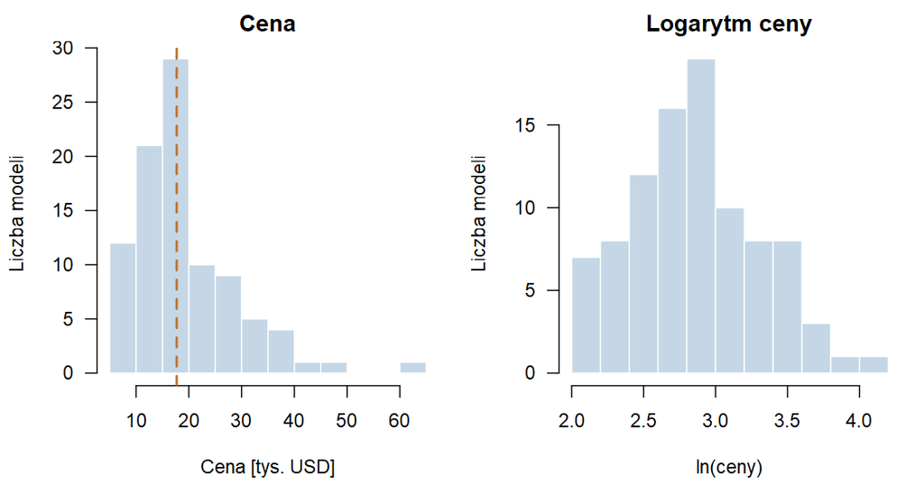

Rysunek 1: Rozkład ceny w skali oryginalnej oraz po logarytmowaniu.

```r
par(mfrow = c(1, 2), family = "sans", mar = c(4.3, 4.2, 2, 1), las = 1, bty = "l")
hist(dane$cena, breaks = "FD", col = "#C5D7E6", border = "white",
     main = "Cena", xlab = "Cena [tys. USD]", ylab = "Liczba modeli")
abline(v = median(dane$cena), col = "#BD7331", lwd = 2, lty = 2)
hist(dane$log_cena, breaks = "FD", col = "#C5D7E6", border = "white",
     main = "Logarytm ceny", xlab = "ln(ceny)", ylab = "Liczba modeli")
par(mfrow = c(1, 1))
```

Rozkład ceny jest prawostronnie asymetryczny. Po logarytmowaniu droższe pojazdy mają mniejszy wpływ na skalę wykresu. Wybór tej skali nie jest testem normalności błędów; o ich rozkładzie wnioskujemy dopiero po dopasowaniu modelu.

### Pochodzenie producenta a cena

**Kod**

```r
z <- pochodzenie_opis
names(z) <- c("Producent", "N", "Średnia ceny", "Mediana ceny", "SD ceny")
z$N <- as.character(z$N)
tabela(z, "Cena [tys. USD] według pochodzenia producenta", cyfry = 2)
```

Cena [tys. USD] według pochodzenia producenta

| Producent | N | Średnia ceny | Mediana ceny | SD ceny |
| --- | --- | --- | --- | --- |
| USA | 48 | 18,57 | 16,30 | 7,82 |
| spoza USA | 45 | 20,51 | 19,10 | 11,31 |

**Kod**

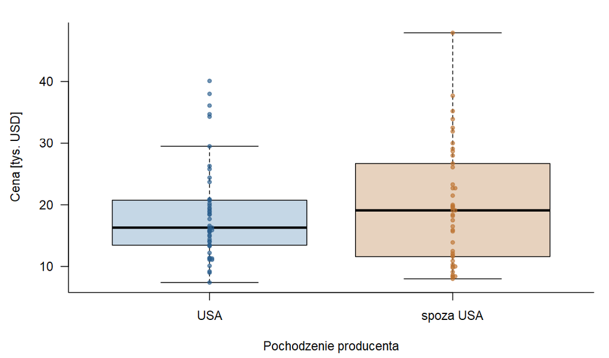

Rysunek 2: Ceny samochodów według pochodzenia producenta; każdy punkt oznacza jeden model auta.

```r
par(family = "sans", mar = c(4.3, 4.5, 1.5, 1), las = 1, bty = "l")
boxplot(cena ~ pochodzenie, data = dane, col = c("#C5D7E6", "#E7D2BE"),
        outline = FALSE, xlab = "Pochodzenie producenta", ylab = "Cena [tys. USD]")
stripchart(cena ~ pochodzenie, data = dane, vertical = TRUE, method = "stack",
           add = TRUE, pch = 19, col = adjustcolor(kolory, alpha.f = .65), cex = .65)
```

Porównanie tych grup jest opisem bez kontroli parametrów technicznych. Różnice mogą wynikać ze struktury oferowanych samochodów. Ich warunkowy odpowiednik ocenimy po uwzględnieniu mocy i masy.

### Parametry techniczne a cena

**Kod**

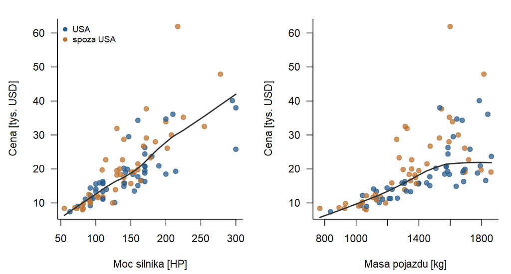

Rysunek 3: Moc silnika i masa pojazdu a cena; kolory oznaczają pochodzenie producenta. Linie przedstawiają wyłącznie lokalne zależności dwuwymiarowe.

```r
par(mfrow = c(1, 2), family = "sans", mar = c(4.3, 4.5, 1.5, 1), las = 1, bty = "l")
plot(dane$moc_hp, dane$cena, pch = 19, col = adjustcolor(kolor_punktu, .75),
     xlab = "Moc silnika [HP]", ylab = "Cena [tys. USD]")
lines(lowess(dane$moc_hp, dane$cena), lwd = 2, col = "#333333")
legend("topleft", legend = names(kolory), col = kolory, pch = 19, bty = "n", cex = .8)
plot(dane$masa_kg, dane$cena, pch = 19, col = adjustcolor(kolor_punktu, .75),
     xlab = "Masa pojazdu [kg]", ylab = "Cena [tys. USD]")
lines(lowess(dane$masa_kg, dane$cena), lwd = 2, col = "#333333")
par(mfrow = c(1, 1))
```

### Korelacje

**Kod**

```r
z <- as.data.frame(korelacje)
names(z) <- c("Cena", "ln(ceny)", "Moc", "Masa")
z <- cbind(Zmienna = c("Cena", "ln(ceny)", "Moc", "Masa"), z)
tabela(z, "Współczynniki korelacji Pearsona", cyfry = 3)
```

Współczynniki korelacji Pearsona

| Zmienna | Cena | ln(ceny) | Moc | Masa |
| --- | --- | --- | --- | --- |
| Cena | 1,000 | 0,958 | 0,788 | 0,647 |
| ln(ceny) | 0,958 | 1,000 | 0,825 | 0,764 |
| Moc | 0,788 | 0,825 | 1,000 | 0,739 |
| Masa | 0,647 | 0,764 | 0,739 | 1,000 |

Korelacja mocy i masy wynosi 0,739. Predyktory częściowo przekazują tę samą informację. Korelacje dwuwymiarowe nie opisują odrębnego związku każdego z nich z ceną po uwzględnieniu pozostałych cech.

## Budowa modelu

### Modele kandydackie

Zbudowano cztery modele o rosnącej złożoności, zawsze na tych samych 93 obserwacjach:

1. **M1:** moc silnika — podstawowy opis osiągów.
2. **M2:** moc silnika i masa — dodatkowa informacja o wielkości pojazdu.
3. **M3:** moc, masa i pochodzenie producenta — uwzględnienie różnic między grupami producentów.
4. **M4:** jak M3 oraz kwadraty wycentrowanej mocy i masy — dopuszczenie krzywizny obu zależności.

**Kod**

```r
M1 <- lm(log_cena ~ moc10, data = dane)
M2 <- lm(log_cena ~ moc10 + masa100, data = dane)
M3 <- lm(log_cena ~ moc10 + masa100 + pochodzenie, data = dane)
M4 <- lm(log_cena ~ moc10 + masa100 + pochodzenie +
           I(moc10^2) + I(masa100^2), data = dane)
```

### Porównanie modeli — kryteria informacyjne

**Kod**

```r
z <- porownanie[c("Model", "Parametry", "RSS", "R2", "R2_skorygowane", "AIC", "BIC", "Delta_AIC")]
names(z) <- c("Model", "Współczynniki", "RSS", "R²", "Skor. R²", "AIC", "BIC", "ΔAIC")
z$Współczynniki <- as.character(z$Współczynniki)
tabela(z, "Porównanie modeli logarytmu ceny", cyfry = 3)
```

Porównanie modeli logarytmu ceny

| Model | Współczynniki | RSS | R² | Skor. R² | AIC | BIC | ΔAIC |
| --- | --- | --- | --- | --- | --- | --- | --- |
| M1 | 2 | 6,085 | 0,680 | 0,677 | 16,332 | 23,929 | 27,587 |
| M2 | 3 | 5,088 | 0,732 | 0,727 | 1,693 | 11,824 | 12,949 |
| M3 | 4 | 4,551 | 0,761 | 0,753 | -6,680 | 5,983 | 4,576 |
| M4 | 6 | 4,150 | 0,782 | 0,769 | -11,255 | 6,473 | 0,000 |

Liczba współczynników obejmuje wyraz wolny. W obliczeniu AIC i BIC funkcje R uwzględniają dodatkowo parametr wariancji błędu. Ujemne AIC jest dopuszczalne: znaczenie mają różnice między modelami, a nie znak kryterium.

### Porównanie modeli — częściowe testy F

**Kod**

```r
z <- p_tabela(testy_F)
names(z) <- c("Porównanie", "Dodane df", "F", "p")
z$`Dodane df` <- as.character(z$`Dodane df`)
tabela(z, "Testy F dla kolejnych rozszerzeń modeli", cyfry = 3)
```

Testy F dla kolejnych rozszerzeń modeli

| Porównanie | Dodane df | F | p |
| --- | --- | --- | --- |
| M2 vs M1 | 1 | 17,632 | < 0,001 |
| M3 vs M2 | 1 | 10,502 | 0,002 |
| M4 vs M3 | 2 | 4,202 | 0,018 |

Dodanie masy oraz pochodzenia producenta poprawia dopasowanie w tej próbie. Łączne rozszerzenie o dwa składniki kwadratowe daje $p$ = 0,018. Wynik dotyczy obu dodanych składników razem i nie dowodzi istotności każdego z nich oddzielnie.

### Wybór modelu końcowego

Do szczegółowej interpretacji wybrano **M4**, który ma najniższe AIC w rozpatrywanym zestawie. Skorygowane $R^2$ rośnie z 0,753 dla M3 do 0,769 dla M4. BIC nieznacznie preferuje M3, co wskazuje, że korzyść z rozszerzenia należy zestawić z większą złożonością.

Nie zakładamy, że M4 jest uniwersalnie najlepszym modelem. Wybór postaci po obejrzeniu danych powoduje, że zwykłe przedziały i testy nie uwzględniają całej niepewności tego procesu. Dalej przedstawiamy walidację ustalonych modeli, diagnostykę oraz analizę wrażliwości.

## Ocena dopasowania modelu końcowego

### Miary ogólne

**Kod**

```r
s <- summary(model)
miary <- data.frame(
  Miara = c("Liczba obserwacji", "Liczba współczynników", "Stopnie swobody reszt",
            "R² — logarytm ceny", "Skorygowane R² — logarytm ceny",
            "Błąd standardowy reszt — skala log", "AIC", "BIC"),
  Wartosc = c(nobs(model), length(coef(model)), df.residual(model),
              s$r.squared, s$adj.r.squared, s$sigma, AIC(model), BIC(model)))
miary$Wartosc <- c(as.character(miary$Wartosc[1:3]), fmt(miary$Wartosc[4:8], 3))
names(miary) <- c("Miara", "Wartość")
tabela(miary, "Miary dopasowania modelu M4")
```

Miary dopasowania modelu M4

| Miara | Wartość |
| --- | --- |
| Liczba obserwacji | 93 |
| Liczba współczynników | 6 |
| Stopnie swobody reszt | 87 |
| R² — logarytm ceny | 0,782 |
| Skorygowane R² — logarytm ceny | 0,769 |
| Błąd standardowy reszt — skala log | 0,218 |
| AIC | -11,255 |
| BIC | 6,473 |

Model opisuje **78,2% zróżnicowania logarytmu ceny** w tej próbie. To wynik dopasowania do tych samych danych, na których oszacowano współczynniki. Nie oznacza, że model prognozuje ceny nowych samochodów z taką samą dokładnością.

### Ceny obserwowane i dopasowane

**Kod**

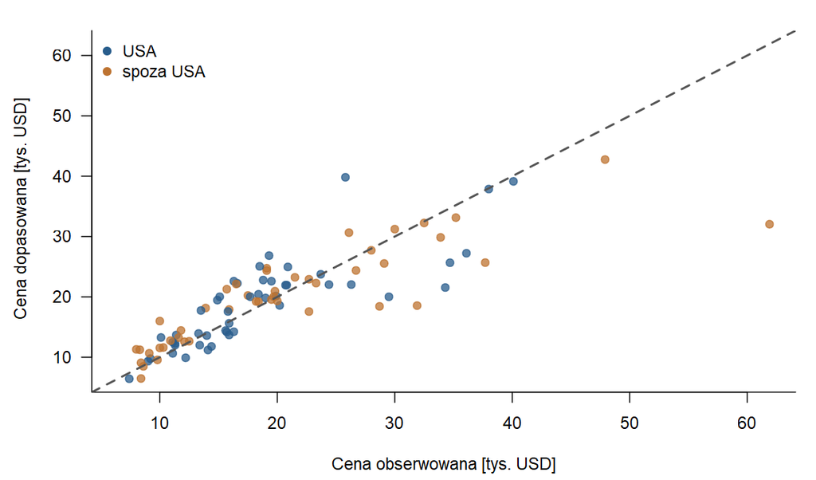

Rysunek 4: Ceny obserwowane i dopasowane przez M4 po korekcie Duana. Jest to ocena na danych użytych do estymacji.

```r
pred_ucz <- exp(fitted(model)) * smearing
zakres <- range(c(dane$cena, pred_ucz))
par(family = "sans", mar = c(4.3, 4.5, 1.5, 1), las = 1, bty = "l")
plot(dane$cena, pred_ucz, pch = 19, col = adjustcolor(kolor_punktu, .75),
     xlim = zakres, ylim = zakres, xlab = "Cena obserwowana [tys. USD]",
     ylab = "Cena dopasowana [tys. USD]")
abline(0, 1, lty = 2, col = "#555555", lwd = 2)
legend("topleft", legend = names(kolory), col = kolory, pch = 19, bty = "n")
```

### Walidacja krzyżowa

**Kod**

```r
z <- cv_tabela
z$Model[z$Model == "Srednia uczaca"] <- "Średnia z części uczącej"
names(z) <- c("Model", "RMSE", "SD RMSE", "MAE", "SD MAE", "R² pred.")
tabela(z, "Walidacja 5-krotna × 20 powtórzeń; błędy w tys. USD", cyfry = 3)
```

Walidacja 5-krotna × 20 powtórzeń; błędy w tys. USD

| Model | RMSE | SD RMSE | MAE | SD MAE | R² pred. |
| --- | --- | --- | --- | --- | --- |
| Średnia z części uczącej | 9,730 | 0,075 | 7,241 | 0,064 | -0,026 |
| M1 | 7,255 | 0,257 | 4,469 | 0,098 | 0,429 |
| M2 | 6,515 | 0,194 | 4,090 | 0,093 | 0,540 |
| M3 | 6,014 | 0,156 | 3,811 | 0,104 | 0,608 |
| M4 | 5,834 | 0,140 | 3,679 | 0,118 | 0,631 |
| M3 bez logarytmu | 5,870 | 0,117 | 4,052 | 0,114 | 0,627 |

Dla M4 średni RMSE wynosi **5,83 tys. USD**, a MAE **3,68 tys. USD**. Model oparty wyłącznie na średniej z części uczącej ma RMSE 9,73 tys. USD. Oznacza to redukcję RMSE o około 40,0% względem tej prostej prognozy.

Poprawa M4 względem M3 jest mniejsza: RMSE spada z 6,01 do 5,83 tys. USD. Model M3 bez logarytmowania osiąga RMSE 5,87 tys. USD, więc jego wynik jest zbliżony do M4. Samo logarytmowanie nie daje tu dużej przewagi w RMSE; uzasadnia je również interpretacja względna i MAE.

Wartości SD pokazują zmienność między losowymi podziałami, **nie są przedziałami ufności**. Powtórzenia wykorzystują te same samochody i nie są niezależnymi próbami. Walidacja dotyczy czterech ustalonych postaci modeli, a nie całego procesu ich wyboru; do pełnej oceny procedury selekcji potrzebna byłaby walidacja zagnieżdżona lub nowa próba.

**Kod**

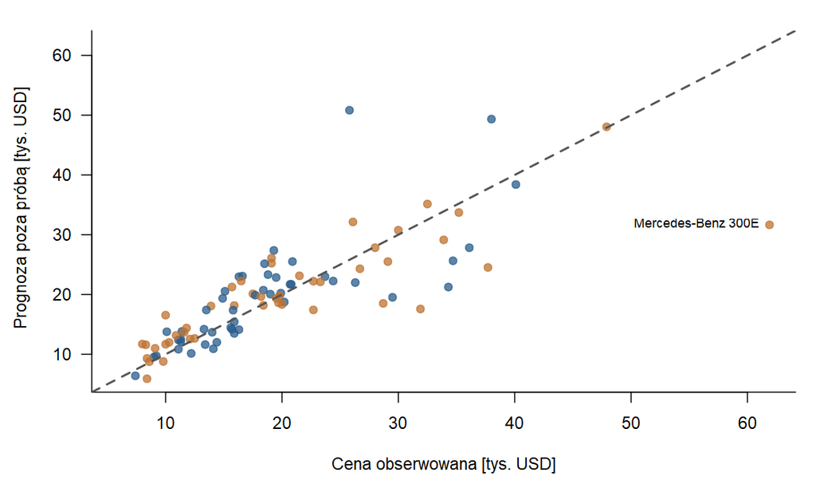

Rysunek 5: Prognozy poza próbą uczącą dla pierwszego powtórzenia 5-krotnej walidacji. Każdy samochód prognozowano modelem uczonym bez jego udziału.

```r
pred_oof <- cv_pred[, "M4", 1]
zakres <- range(c(dane$cena, pred_oof))
par(family = "sans", mar = c(4.3, 4.5, 1.5, 1), las = 1, bty = "l")
plot(dane$cena, pred_oof, pch = 19, col = adjustcolor(kolor_punktu, .75),
     xlim = zakres, ylim = zakres, xlab = "Cena obserwowana [tys. USD]",
     ylab = "Prognoza poza próbą [tys. USD]")
abline(0, 1, lty = 2, col = "#555555", lwd = 2)
j <- which.max(abs(dane$cena - pred_oof))
text(dane$cena[j], pred_oof[j], dane$samochod[j], pos = 2, cex = .75)
```

**AdnotacjaDlaczego nie ma macierzy pomyłek i krzywej ROC?**

Cena jest wielkością ciągłą. W tym zadaniu właściwe są błędy prognoz, wykresy dopasowania i analiza reszt. Macierz pomyłek, czułość i ROC dotyczą klasyfikacji, np. niskiej masy urodzeniowej w przykładzie z zajęć.

## Sprawdzanie założeń

### Postać zależności

Porównanie M3 z M4 wykazało poprawę po uwzględnieniu krzywizny. Aby zilustrować jej znaczenie, przedstawiamy zależności warunkowe przy ustalonych pozostałych cechach. Na wykresach nie nakładamy surowych cen, ponieważ odpowiadają one różnym masom, mocom i grupom producentów.

**Kod**

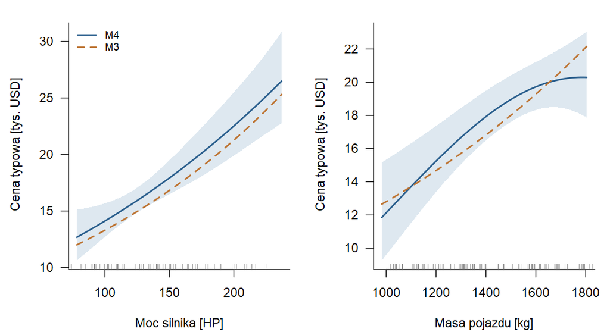

Rysunek 6: Zależności warunkowe ceny typowej: M3 i M4. Ustalono producenta z USA; przy zmianie mocy masa wynosi 1400 kg, a przy zmianie masy moc wynosi 150 HP. Cieniowanie przedstawia punktowe 95% przedziały HC3 dla M4. Kreski pokazują rozmieszczenie obserwowanych wartości.

```r
wykres_warunkowy <- function(zmienna, podpis) {
  zakres <- quantile(dane[[zmienna]], c(.05, .95))
  grid <- data.frame(moc_hp = rep(150, 160), masa_kg = rep(1400, 160),
                     pochodzenie = factor(rep("USA", 160), levels = levels(dane$pochodzenie)))
  grid[[zmienna]] <- seq(zakres[1], zakres[2], length.out = 160)
  grid$moc10 <- (grid$moc_hp - 150) / 10
  grid$masa100 <- (grid$masa_kg - 1400) / 100
  eta <- predict(model, newdata = grid)
  xx <- model.matrix(delete.response(terms(model)), grid, contrasts.arg = model$contrasts)
  se <- sqrt(rowSums((xx %*% V_hc3) * xx))
  low <- exp(eta - qt(.975, df.residual(model)) * se)
  high <- exp(eta + qt(.975, df.residual(model)) * se)
  stary <- exp(predict(modele$M3, newdata = grid))
  x <- grid[[zmienna]]
  plot(x, exp(eta), type = "n", ylim = range(c(low, high, stary)),
       xlab = podpis, ylab = "Cena typowa [tys. USD]")
  polygon(c(x, rev(x)), c(low, rev(high)), col = "#DEE8F0", border = NA)
  lines(x, exp(eta), col = "#285D8C", lwd = 2)
  lines(x, stary, col = "#BD7331", lwd = 2, lty = 2)
  rug(dane[[zmienna]], col = "#666666", ticksize = .025)
}
par(mfrow = c(1, 2), family = "sans", mar = c(4.3, 4.5, 1.5, 1), las = 1, bty = "l")
wykres_warunkowy("moc_hp", "Moc silnika [HP]")
legend("topleft", c("M4", "M3"), col = c("#285D8C", "#BD7331"),
       lty = c(1, 2), lwd = 2, bty = "n", cex = .8)
wykres_warunkowy("masa_kg", "Masa pojazdu [kg]")
par(mfrow = c(1, 1))
```

Dodatkowe porównanie M4 z modelem zawierającym także sześciany mocy i masy daje $p$ = 0,048. To eksploracyjny sygnał, że kwadratowa postać może nie opisywać całej struktury danych. Nie rozbudowujemy wielomianu aż do uzyskania nieistotnego testu. M4 traktujemy jako przybliżenie o ograniczonej złożoności, a wyniki tego sprawdzenia uwzględniamy w dyskusji.

### Rozkład i wariancja reszt

**Kod**

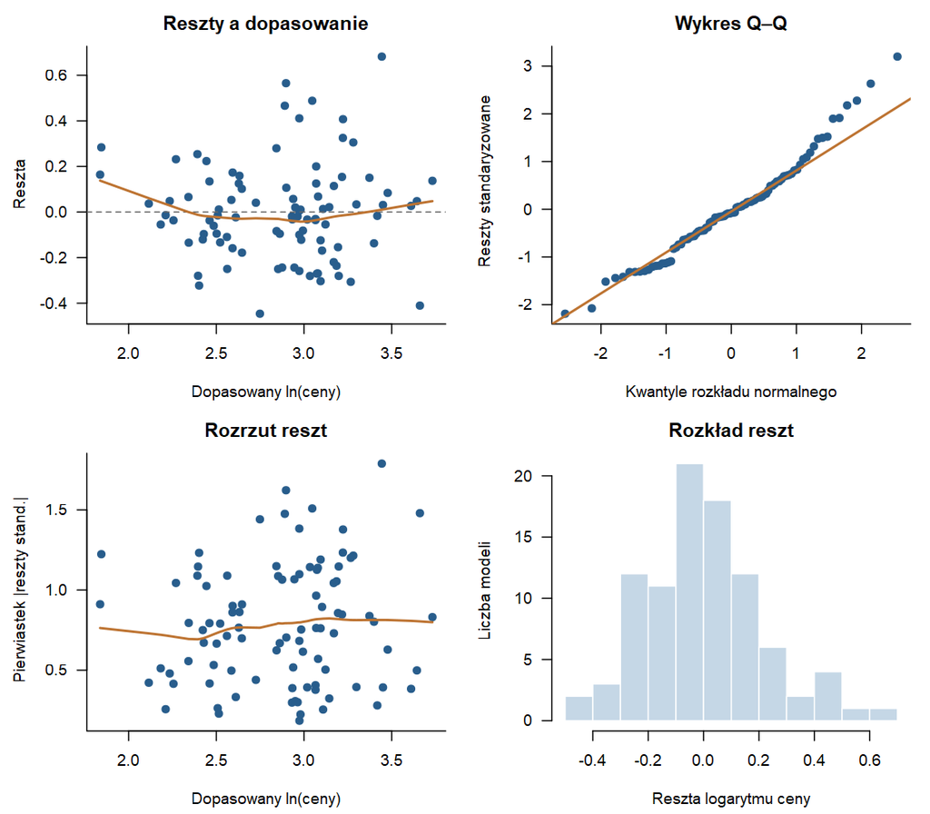

Rysunek 7: Diagnostyka M4: reszty a wartości dopasowane, wykres kwantylowy, wykres rozrzutu reszt studentyzowanych i histogram reszt.

```r
par(mfrow = c(2, 2), family = "sans", mar = c(4.3, 4.5, 2.4, 1), las = 1, bty = "l")
plot(fitted(model), residuals(model), pch = 19, col = "#285D8C",
     xlab = "Dopasowany ln(ceny)", ylab = "Reszta", main = "Reszty a dopasowanie")
abline(h = 0, lty = 2, col = "#666666")
lines(lowess(fitted(model), residuals(model)), col = "#BD7331", lwd = 2)
qqnorm(rstandard(model), pch = 19, col = "#285D8C", main = "Wykres Q–Q",
       xlab = "Kwantyle rozkładu normalnego", ylab = "Reszty standaryzowane")
qqline(rstandard(model), col = "#BD7331", lwd = 2)
plot(fitted(model), sqrt(abs(rstandard(model))), pch = 19, col = "#285D8C",
     xlab = "Dopasowany ln(ceny)", ylab = "Pierwiastek |reszty stand.|", main = "Rozrzut reszt")
lines(lowess(fitted(model), sqrt(abs(rstandard(model)))), col = "#BD7331", lwd = 2)
hist(residuals(model), breaks = "FD", col = "#C5D7E6", border = "white",
     main = "Rozkład reszt", xlab = "Reszta logarytmu ceny", ylab = "Liczba modeli")
par(mfrow = c(1, 1))
```

**Kod**

```r
z <- p_tabela(diagnostyka)
z$Test <- c("Shapiro–Wilk: normalność reszt", "Koenker–Breusch–Pagan: wariancja",
            "Dodatkowe składniki sześcienne: F")
tabela(z, "Pomocnicze testy diagnostyczne", cyfry = 3)
```

Pomocnicze testy diagnostyczne

| Test | Statystyka | p |
| --- | --- | --- |
| Shapiro–Wilk: normalność reszt | 0,971 | 0,035 |
| Koenker–Breusch–Pagan: wariancja | 4,372 | 0,497 |
| Dodatkowe składniki sześcienne: F | 3,140 | 0,048 |

Test Shapiro–Wilka daje $p$ = 0,035. Przy poziomie 0,05 wskazuje to na odstępstwo od normalności. Test wariancji daje $p$ = 0,497 i nie dostarcza podstaw do odrzucenia hipotezy o stałej wariancji względem uwzględnionych predyktorów. **Nie potwierdza jednak jej spełnienia** i nie bada wszystkich możliwych postaci heteroskedastyczności.

Do interpretacji efektów wykorzystujemy także przedziały HC3. Klasyczne przedziały predykcji pokazane dalej mają charakter orientacyjny, ponieważ odstępstwa rozkładu reszt osłabiają uzasadnienie ich nominalnego pokrycia 95%.

### Współliniowość predyktorów

**Kod**

```r
z <- vif_tabela
z$Parametr <- c("Moc — składnik liniowy", "Masa — składnik liniowy",
               "Producent spoza USA", "Kwadrat mocy", "Kwadrat masy")
tabela(z, "Współczynniki VIF dla kolumn macierzy modelu M4", cyfry = 3)
```

Współczynniki VIF dla kolumn macierzy modelu M4

| Parametr | VIF |
| --- | --- |
| Moc — składnik liniowy | 5,801 |
| Masa — składnik liniowy | 4,224 |
| Producent spoza USA | 1,137 |
| Kwadrat mocy | 2,884 |
| Kwadrat masy | 1,567 |

Najwyższy VIF wynosi 5,80. Wskazuje to na częściowe nakładanie się informacji o parametrach technicznych, a nie na doskonałą współliniowość. Składniki wielomianowe są również powiązane ze swoimi składnikami liniowymi. Progi VIF nie są testami istotności; ocenę stabilności uzupełniamy błędami standardowymi i analizą wpływu obserwacji.

### Obserwacje wpływowe i analiza wrażliwości

**Kod**

```r
z <- head(diag_obs, 5)
names(z) <- c("Wiersz", "Samochód", "Cena", "Cook", "Dźwignia", "Reszta student.")
z$Wiersz <- as.character(z$Wiersz)
tabela(z, "Obserwacje o największej odległości Cooka", cyfry = 3)
```

Obserwacje o największej odległości Cooka

| Wiersz | Samochód | Cena | Cook | Dźwignia | Reszta student. |
| --- | --- | --- | --- | --- | --- |
| 28 | Dodge Stealth | 25,800 | 0,285 | 0,263 | -2,239 |
| 39 | Geo Metro | 8,400 | 0,122 | 0,247 | 1,508 |
| 59 | Mercedes-Benz 300E | 61,900 | 0,085 | 0,048 | 3,386 |
| 52 | Lincoln Town_Car | 36,100 | 0,041 | 0,102 | 1,486 |
| 58 | Mercedes-Benz 190E | 31,900 | 0,040 | 0,033 | 2,728 |

**Kod**

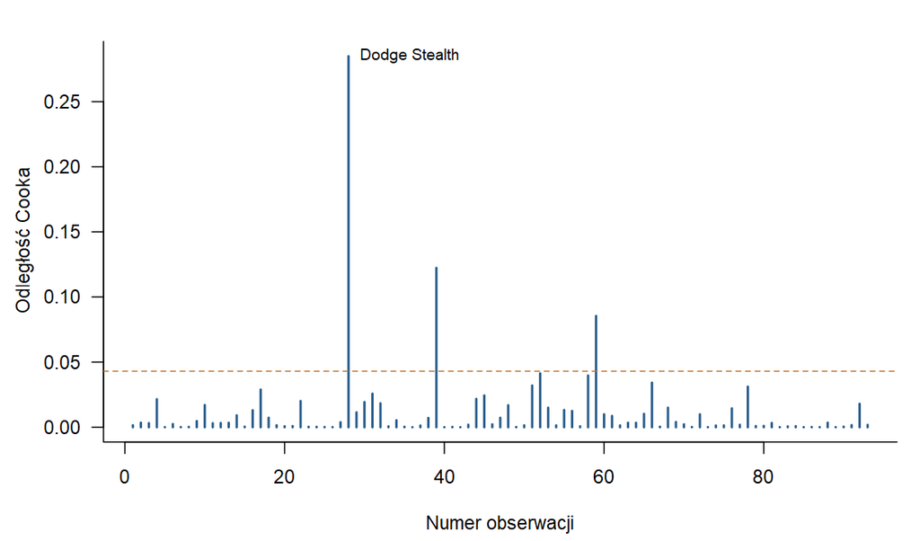

Rysunek 8: Odległości Cooka dla M4. Linia 4/n jest pomocniczym sygnałem do przeglądu danych, a nie automatyczną regułą usuwania.

```r
par(family = "sans", mar = c(4.3, 4.5, 1.8, 1), las = 1, bty = "l")
plot(cooks.distance(model), type = "h", lwd = 2, col = "#285D8C",
     xlab = "Numer obserwacji", ylab = "Odległość Cooka")
abline(h = 4 / n, col = "#BD7331", lty = 2)
text(id_max, cooks.distance(model)[id_max], dane$samochod[id_max], pos = 4, cex = .8)
```

Największy wpływ ma **Dodge Stealth**. Dodatkowo dopasowano ten sam model po pominięciu wyłącznie tej obserwacji. Służy to ocenie wrażliwości; podstawowe wyniki nadal wykorzystują wszystkie 93 samochody.

**Kod**

```r
z <- wrazliwosc
z$Parametr <- parametry$Parametr
names(z) <- c("Parametr", "Pełna próba", "Bez najbardziej wpływowego auta")
tabela(z, "Wrażliwość współczynników na jedną obserwację", cyfry = 5)
```

Wrażliwość współczynników na jedną obserwację

| Parametr | Pełna próba | Bez najbardziej wpływowego auta |
| --- | --- | --- |
| Wyraz wolny: 150 HP, 1400 kg, USA | 2,88624 | 2,88037 |
| Moc: składnik liniowy | 0,04673 | 0,04565 |
| Masa: składnik liniowy | 0,06433 | 0,06845 |
| Producent spoza USA vs USA | 0,15874 | 0,15421 |
| Moc: składnik kwadratowy | -0,00021 | 0,00052 |
| Masa: składnik kwadratowy | -0,00832 | -0,00925 |

Najbardziej zmieniają się składniki związane z krzywizną. W szczególności słabo określony kwadrat mocy może zmienić znak, co przestrzega przed nadawaniem mu samodzielnej interpretacji mechanicznej. Nietypowe auto nie musi być błędem pomiaru; może reprezentować odmienny segment rynku.

### Niezależność i odporna ocena niepewności

W danych nie ma powtórzeń tego samego modelu, ale różne auta tego samego producenta mogą mieć wspólne cechy konstrukcyjne i politykę cenową. Niezależności nie da się wykazać testem autokorelacji po numerze wiersza, ponieważ kolejność nie jest osią czasu. Losowa walidacja ocenia przede wszystkim prognozowanie podobnych modeli z tego zbioru. Ocena dla zupełnie nowych producentów wymagałaby walidacji grupowanej według marki.

**Kod**

```r
z <- p_tabela(parametry_hc3, c("p_klasyczne", "p_HC3"))
names(z) <- c("Parametr", "SE klasyczne", "SE HC3", "p klasyczne", "p HC3")
tabela(z, "Porównanie klasycznej i odpornej oceny niepewności", cyfry = 4)
```

Porównanie klasycznej i odpornej oceny niepewności

| Parametr | SE klasyczne | SE HC3 | p klasyczne | p HC3 |
| --- | --- | --- | --- | --- |
| Wyraz wolny: 150 HP, 1400 kg, USA | 0,0428 | 0,0420 | < 0,001 | < 0,001 |
| Moc: składnik liniowy | 0,0105 | 0,0091 | < 0,001 | < 0,001 |
| Masa: składnik liniowy | 0,0175 | 0,0150 | < 0,001 | < 0,001 |
| Producent spoza USA vs USA | 0,0483 | 0,0486 | 0,001 | 0,002 |
| Moc: składnik kwadratowy | 0,0009 | 0,0010 | 0,811 | 0,831 |
| Masa: składnik kwadratowy | 0,0037 | 0,0039 | 0,029 | 0,036 |

HC3 jest analizą odporności na nierówność wariancji przy niezależnych obserwacjach, a nie sposobem potwierdzenia wszystkich założeń. Przedziały i wartości $p$ oparte na HC3 są przybliżone; użyto rozkładu t z 87 stopniami swobody.

## Interpretacja parametrów modelu

### Współczynniki regresji

**Kod**

```r
z <- p_tabela(parametry)
names(z) <- c("Parametr", "β", "SE", "95% CI dol.", "95% CI gór.", "t", "p")
tabela(z, "Współczynniki M4 w skali logarytmu ceny; klasyczne przedziały t", cyfry = 4)
```

Współczynniki M4 w skali logarytmu ceny; klasyczne przedziały t

| Parametr | β | SE | 95% CI dol. | 95% CI gór. | t | p |
| --- | --- | --- | --- | --- | --- | --- |
| Wyraz wolny: 150 HP, 1400 kg, USA | 2,8862 | 0,0428 | 2,8012 | 2,9713 | 67,4766 | < 0,001 |
| Moc: składnik liniowy | 0,0467 | 0,0105 | 0,0259 | 0,0675 | 4,4625 | < 0,001 |
| Masa: składnik liniowy | 0,0643 | 0,0175 | 0,0296 | 0,0991 | 3,6778 | < 0,001 |
| Producent spoza USA vs USA | 0,1587 | 0,0483 | 0,0627 | 0,2548 | 3,2855 | 0,001 |
| Moc: składnik kwadratowy | -0,0002 | 0,0009 | -0,0020 | 0,0015 | -0,2403 | 0,811 |
| Masa: składnik kwadratowy | -0,0083 | 0,0037 | -0,0158 | -0,0009 | -2,2218 | 0,029 |

Wyraz wolny odpowiada oczekiwanemu logarytmowi ceny samochodu o mocy 150 HP, masie 1400 kg i producencie z USA. Jego eksponenta wynosi 17,93 tys. USD i opisuje cenę typową tego profilu.

Nie interpretujemy samego współczynnika liniowego mocy jako stałego efektu dodatkowych 10 HP w całym zakresie. Podobnie postępujemy z masą. Kwadrat mocy samodzielnie nie wykazuje wyraźnego związku warunkowego z ceną; łączna poprawa M4 nie oznacza istotności obu kwadratów.

### Wielkość związków w skali procentowej

**Kod**

```r
z <- efekty[c("Porownanie", "Zmiana_proc", "HC3_CI_dol", "HC3_CI_gora", "p_HC3")]
z <- p_tabela(z, "p_HC3")
names(z) <- c("Porównanie", "Różnica [%]", "95% CI HC3 dol.", "95% CI HC3 gór.", "p HC3")
tabela(z, "Warunkowe względne różnice ceny typowej", cyfry = 2)
```

Warunkowe względne różnice ceny typowej

| Porównanie | Różnica [%] | 95% CI HC3 dol. | 95% CI HC3 gór. | p HC3 |
| --- | --- | --- | --- | --- |
| Moc: 100 -> 110 HP | 4,98 | 1,61 | 8,47 | 0,004 |
| Moc: 150 -> 160 HP | 4,76 | 3,02 | 6,53 | < 0,001 |
| Moc: 200 -> 210 HP | 4,54 | 2,86 | 6,25 | < 0,001 |
| Masa: 1200 -> 1300 kg | 9,34 | 4,64 | 14,25 | < 0,001 |
| Masa: 1400 -> 1500 kg | 5,76 | 2,85 | 8,75 | < 0,001 |
| Masa: 1600 -> 1700 kg | 2,30 | -1,66 | 6,41 | 0,256 |
| Producent: spoza USA vs USA | 17,20 | 6,42 | 29,08 | 0,002 |

Przy pozostałych cechach utrzymanych na tym samym poziomie:

- **Moc:** różnica między 150 a 160 HP wiąże się z ceną typową wyższą o 4,8%, z 95% przedziałem HC3 od 3,0% do 6,5%.
- **Masa:** różnica między 1400 a 1500 kg wiąże się z ceną typową wyższą o 5,8%. Dla cięższych aut ta sama różnica masy ma w modelu słabszy związek z ceną.
- **Pochodzenie producenta:** samochody producentów spoza USA mają oszacowaną cenę typową wyższą o 17,2% względem producentów z USA, przy takiej samej mocy i masie. Przedział HC3 wynosi od 6,4% do 29,1%.

Są to porównania profili w modelu. Nie oznaczają, że zwiększenie masy istniejącego samochodu lub zmiana kraju pochodzenia jego producenta spowoduje taki wzrost ceny. W analizie nie kontrolowano wszystkich różnic wyposażenia, marki i segmentu.

**Kod**

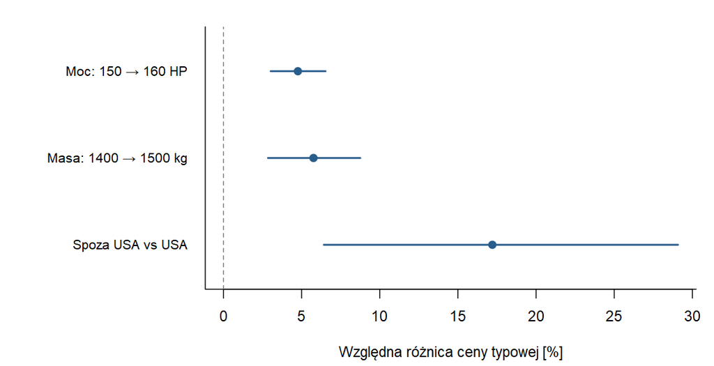

Rysunek 9: Wybrane względne różnice ceny typowej i 95% przedziały HC3. Zerowa różnica oznacza brak związku dla danego kontrastu.

```r
z <- efekty[c(2, 5, 7), ]
lab <- c("Moc: 150 → 160 HP", "Masa: 1400 → 1500 kg", "Spoza USA vs USA")
par(family = "sans", mar = c(4.3, 11.5, 1.5, 1), las = 1, bty = "l")
plot(z$Zmiana_proc, 3:1, xlim = range(c(0, z$HC3_CI_dol, z$HC3_CI_gora)),
     ylim = c(.6, 3.4), yaxt = "n", pch = 19, col = "#285D8C", cex = 1.1,
     xlab = "Względna różnica ceny typowej [%]", ylab = "")
axis(2, at = 3:1, labels = lab, tick = FALSE, cex.axis = .9)
segments(z$HC3_CI_dol, 3:1, z$HC3_CI_gora, 3:1, col = "#285D8C", lwd = 2)
abline(v = 0, lty = 2, col = "#777777")
```

**WażneIstotność statystyczna a znaczenie praktyczne**

Wartość $p$ nie opisuje wielkości ani przydatności związku. Wnioski opieramy na różnicach procentowych, ich niepewności i błędach prognoz. Przedział obejmujący zero nie dowodzi braku związku; pokazuje zakres wartości zgodnych z przyjętą procedurą i danymi.

## Predykcja dla wybranych obserwacji

Rozważmy dwa przykładowe profile mieszczące się w marginalnych zakresach danych. Nie są to dodatkowe pomiary ani rzeczywiste oferty sprzedaży.

- **Profil A:** moc 100 HP, masa 1100 kg, producent z USA.
- **Profil B:** moc 180 HP, masa 1500 kg, producent spoza USA.

### Cena typowa i niepewność oszacowania

**Kod**

```r
z <- predykcje[c("Profil", "Log_ceny", "Cena_typowa", "CI_typowa_dol", "CI_typowa_gora")]
names(z) <- c("Profil", "Przew. ln(ceny)", "Cena typowa", "95% CI HC3 dol.", "95% CI HC3 gór.")
tabela(z, "Przewidywana cena typowa i jej punktowe przedziały HC3; ceny w tys. USD", cyfry = 2)
```

Przewidywana cena typowa i jej punktowe przedziały HC3; ceny w tys. USD

| Profil | Przew. ln(ceny) | Cena typowa | 95% CI HC3 dol. | 95% CI HC3 gór. |
| --- | --- | --- | --- | --- |
| A: 100 HP, 1100 kg, USA | 2,38 | 10,80 | 9,97 | 11,70 |
| B: 180 HP, 1500 kg, spoza USA | 3,24 | 25,52 | 23,11 | 28,17 |

Eksponenta dopasowanego logarytmu oznacza średnią geometryczną ceny. Nazwanie jej medianą wymagałoby dodatkowego założenia symetrii błędów na skali logarytmicznej, dlatego w tabelach stosujemy określenie **cena typowa**.

### Co dzieje się krok po kroku?

Najpierw obliczamy wycentrowaną moc i masę, następnie ich kwadraty i wskaźnik producenta spoza USA. Wkłady poszczególnych składników sumują się do przewidywanego logarytmu ceny.

**Kod**

```r
wklady <- sweep(X_nowe, 2, coef(model), "*")
z <- data.frame(Składnik = unname(etykiety_parametrow[colnames(X_nowe)]),
                 Profil_A = wklady[1, ], Profil_B = wklady[2, ])
z <- rbind(z, data.frame(Składnik = "Suma: przewidywany logarytm ceny",
                         Profil_A = sum(wklady[1, ]), Profil_B = sum(wklady[2, ])))
names(z) <- c("Składnik", "Profil A", "Profil B")
tabela(z, "Wkłady składników modelu do przewidywanego ln(ceny)", cyfry = 4)
```

Wkłady składników modelu do przewidywanego ln(ceny)

| Składnik | Profil A | Profil B |
| --- | --- | --- |
| Wyraz wolny: 150 HP, 1400 kg, USA | 2,8862 | 2,8862 |
| Moc: składnik liniowy | -0,2337 | 0,1402 |
| Masa: składnik liniowy | -0,1930 | 0,0643 |
| Producent spoza USA vs USA | 0,0000 | 0,1587 |
| Moc: składnik kwadratowy | -0,0053 | -0,0019 |
| Masa: składnik kwadratowy | -0,0749 | -0,0083 |
| Suma: przewidywany logarytm ceny | 2,3794 | 3,2393 |

Dla profilu A otrzymujemy logarytm ceny 2,3794. Po eksponentowaniu cena typowa wynosi **10,80 tys. USD**. Dla profilu B odpowiadające wartości to 3,2393 oraz **25,52 tys. USD**.

Profile różnią się trzema cechami jednocześnie. Ich porównanie ilustruje działanie modelu, ale nie izoluje związku jednego parametru z ceną.

### Średnia arytmetyczna i przedział predykcji

**Kod**

```r
z <- predykcje[c("Profil", "Srednia_Duan", "PI_dol", "PI_gora")]
names(z) <- c("Profil", "Średnia: korekta Duana", "Orientacyjny 95% PI dol.", "Orientacyjny 95% PI gór.")
tabela(z, "Średnia prognozowana i klasyczne przedziały dla pojedynczej ceny; tys. USD", cyfry = 2)
```

Średnia prognozowana i klasyczne przedziały dla pojedynczej ceny; tys. USD

| Profil | Średnia: korekta Duana | Orientacyjny 95% PI dol. | Orientacyjny 95% PI gór. |
| --- | --- | --- | --- |
| A: 100 HP, 1100 kg, USA | 11,05 | 6,93 | 16,82 |
| B: 180 HP, 1500 kg, spoza USA | 26,12 | 16,39 | 39,71 |

Współczynnik korekty Duana wynosi 1,0236. Zwiększa on prognozę średniej względem ceny typowej, ponieważ eksponentowanie jest transformacją nieliniową. W walidacji tę korektę za każdym razem obliczano od nowa wyłącznie z reszt części uczącej.

Przedział ufności dotyczy oszacowania ceny typowej danego profilu, natomiast przedział predykcji obejmuje także rozrzut pojedynczych cen i dlatego jest szerszy. Pokazane przedziały predykcji uzyskano przez eksponentowanie `predict.lm(..., interval = "prediction")`. Zakładają poprawną postać modelu oraz normalne, niezależne błędy o stałej wariancji na skali logarytmicznej. Ze względu na diagnostykę podajemy je **orientacyjnie**, bez deklaracji, że rzeczywiste pokrycie wynosi dokładnie 95%.

## Dyskusja

### Znaczenie uzyskanych wyników

Moc, masa i pochodzenie producenta zawierają istotną informację o zróżnicowaniu cen w tej próbie. Uwzględnienie masy poprawia model oparty na samej mocy, a dodanie pochodzenia producenta wnosi kolejną informację. Kwadratowa postać pozwala opisać słabnięcie związku ceny z masą wśród cięższych samochodów.

Oszacowana różnica związana z pochodzeniem producenta nie jest czystą „premią za zagraniczną markę”. Może obejmować wpływ nieuwzględnionych segmentów, wyposażenia i reputacji marki. Zmienna `Origin` nie opisuje również miejsca zmontowania konkretnego pojazdu.

### Dopasowanie a użyteczność predykcyjna

Wysokie $R^2$ dla logarytmu ceny nie usuwa problemu dużych błędów w tysiącach dolarów. MAE rzędu 3,68 tys. USD oznacza, że model jest użytecznym opisem ogólnych zależności, lecz do dokładnej wyceny konkretnej oferty wymagałby dodatkowych cech. Najdroższe i nietypowe auta są szczególnie trudne do przewidywania.

Wynik M4 jest lepszy od prognozy samej średniej, ale przewaga nad M3 oraz modelem bez logarytmowania jest niewielka. Korzyści z większej złożoności należy rozpatrywać łącznie z niepewnością estymacji i kosztami interpretacji.

### Ograniczenia badania

1. **Zakres danych:** 93 modele z rynku USA w 1993 r. nie reprezentują współczesnej struktury cen ani wszystkich klas pojazdów.
2. **Definicja ceny:** analizowana wielkość jest średnią dwóch wariantów cenowych modelu, a nie średnią z indywidualnych transakcji.
3. **Pominięte cechy:** nie uwzględniono pełnego wyposażenia, jakości, szczegółowego segmentu i efektu marki. Związki nie mają interpretacji przyczynowej.
4. **Postać modelu:** test rozkładu reszt i dodatkowej krzywizny wskazuje, że M4 pozostaje przybliżeniem. HC3 ogranicza część problemów wnioskowania, lecz nie usuwa błędnej specyfikacji.
5. **Stabilność:** obserwacje o nietypowej mocy lub masie wpływają na krzywiznę modelu. Nie należy ekstrapolować poza obserwowany zakres ani uznawać każdej kombinacji parametrów za równie dobrze reprezentowaną.
6. **Walidacja:** losowe podziały nie są testem na nowym rynku, w innym roku ani dla nowych producentów. Dobór modelu po eksploracji zwiększa niepewność, której zwykłe testy w pełni nie obejmują.

Dalsze badanie mogłoby uwzględnić typ pojazdu i markę, porównać regresję ze splajnami oraz zastosować walidację grupowaną według producenta. Takie rozszerzenie należałoby sprawdzić na większej, niezależnej próbie, zamiast zwiększać liczbę parametrów bez ograniczeń w obecnych 93 obserwacjach.

## Wnioski

1. **Parametry techniczne i pochodzenie producenta są związane z ceną.** W modelu końcowym różnica mocy 150–160 HP wiąże się z ceną typową wyższą o około 4,8%, a różnica masy 1400–1500 kg — o 5,8%, przy stałych pozostałych cechach.
2. **Pochodzenie producenta wnosi dodatkową informację.** Oszacowana względna różnica dla producentów spoza USA wynosi 17,2%; nie jest to oszacowanie skutku samego kraju pochodzenia.
3. **Rozszerzenie o krzywiznę poprawia opis próby**, ale nie każda dodana składowa jest indywidualnie istotna. M4 ma $R^2$ = 0,782 dla logarytmu ceny.
4. **Jakość prognoz jest umiarkowana i mierzalna.** W walidacji M4 uzyskał RMSE 5,83 oraz MAE 3,68 tys. USD. Zysk względem prostszych modeli jest znacznie mniejszy niż względem prognozy średniej.
5. **Diagnostyka wyznacza granice interpretacji.** Wyniki należy traktować jako warunkowe zależności w historycznej próbie. Dokładna wycena i przeniesienie modelu na inne populacje wymagają nowych danych i dodatkowej walidacji.

## Literatura

Duan, Naihua. 1983. „Smearing Estimate: A Nonparametric Retransformation Method”. *Journal of the American Statistical Association* 78 (383): 605–10. https://doi.org/10.1080/01621459.1983.10478017.

Lock, Robin H. 1993. „1993 New Car Data”. *Journal of Statistics Education* 1 (1). https://doi.org/10.1080/10691898.1993.11910459.

Schneider, Astrid, Gerhard Hommel, i Maria Blettner. 2010. „Linear Regression Analysis: Part 14 of a Series on Evaluation of Scientific Publications”. *Deutsches Ärzteblatt International* 107 (44): 776–82. https://doi.org/10.3238/arztebl.2010.0776.

## Dodatek: odtwarzalność analizy

Obliczenia wykonano w R. Raport korzysta z lokalnej kopii CSV, a pełny skrypt `R/analiza.R` zapisuje tabele do katalogu `wyniki/`. Wyniki liczbowe w tekście powstają z obiektów R podczas renderowania, więc po zmianie danych nie trzeba ręcznie aktualizować tabel i opisów liczbowych. Interpretację oraz decyzje dotyczące modelu zawsze należy wtedy ponownie sprawdzić.

Ziarno generatora podziałów walidacji to **20261124**. Nie zastosowano losowego usuwania obserwacji ani balansowania próby: zmienną zależną jest cena, a nie klasa.

**Kod**

### Pełny skrypt obliczeniowy R

**Pokaż pełny skrypt R**

```r
# Analiza Cars93. Uruchom z katalogu projektu: source("R/analiza.R")
# Obliczenia wykorzystuja wylacznie funkcje standardowej instalacji R.
options(stringsAsFactors = FALSE, scipen = 5)

plik_danych <- file.path("data", "cars93.csv")
if (file.exists(plik_danych)) {
  surowe <- read.csv(plik_danych, check.names = FALSE)
} else if (requireNamespace("MASS", quietly = TRUE)) {
  surowe <- as.data.frame(MASS::Cars93)
} else {
  stop("Brak data/cars93.csv. Przywroc plik z archiwum albo zainstaluj MASS.")
}

dane <- data.frame(
  id = seq_len(nrow(surowe)),
  samochod = paste(surowe$Manufacturer, surowe$Model),
  cena = surowe$Price,
  moc_hp = surowe$Horsepower,
  masa_kg = surowe$Weight * 0.45359237,
  pochodzenie = factor(ifelse(surowe$Origin == "USA", "USA", "spoza USA"),
                      levels = c("USA", "spoza USA"))
)
stopifnot(nrow(dane) == 93L, !anyNA(dane), all(dane$cena > 0),
          length(unique(dane$samochod)) == nrow(dane))
dane$moc10 <- (dane$moc_hp - 150) / 10
dane$masa100 <- (dane$masa_kg - 1400) / 100
dane$log_cena <- log(dane$cena)
n <- nrow(dane)

# Modele zagniezdzone. Model 4 jest rozszerzeniem o krzywizne obu zaleznosci.
formuly <- list(
  M1 = log_cena ~ moc10,
  M2 = log_cena ~ moc10 + masa100,
  M3 = log_cena ~ moc10 + masa100 + pochodzenie,
  M4 = log_cena ~ moc10 + masa100 + pochodzenie + I(moc10^2) + I(masa100^2)
)
modele <- lapply(formuly, function(f) lm(f, data = dane))
model <- modele$M4
model_surowy <- lm(cena ~ moc10 + masa100 + pochodzenie, data = dane)

fmt <- function(x, digits = 2L) {
  formatC(x, format = "f", digits = digits, decimal.mark = ",", big.mark = " ")
}
fmt_p <- function(p) ifelse(p < .001, "< 0,001", fmt(p, 3))

opis_liczbowy <- function(x) {
  c(N = length(x), Srednia = mean(x), SD = sd(x), Min = min(x),
    Q1 = unname(quantile(x, .25)), Mediana = median(x),
    Q3 = unname(quantile(x, .75)), Max = max(x))
}
statystyki <- as.data.frame(t(sapply(dane[c("cena", "moc_hp", "masa_kg")], opis_liczbowy)))
statystyki$Zmienna <- c("Cena [tys. USD]", "Moc [HP]", "Masa [kg]")
statystyki <- statystyki[c("Zmienna", "N", "Srednia", "SD", "Min", "Q1", "Mediana", "Q3", "Max")]
korelacje <- cor(dane[c("cena", "log_cena", "moc_hp", "masa_kg")])
pochodzenie_opis <- do.call(rbind, lapply(levels(dane$pochodzenie), function(gr) {
  x <- dane$cena[dane$pochodzenie == gr]
  data.frame(Pochodzenie = gr, N = length(x), Srednia = mean(x),
             Mediana = median(x), SD = sd(x))
}))

porownanie <- do.call(rbind, lapply(names(modele), function(nazwa) {
  m <- modele[[nazwa]]; s <- summary(m)
  data.frame(Model = nazwa, Parametry = length(coef(m)),
             RSS = deviance(m), R2 = s$r.squared, R2_skorygowane = s$adj.r.squared,
             AIC = AIC(m), BIC = BIC(m), RSE = s$sigma)
}))
porownanie$Delta_AIC <- porownanie$AIC - min(porownanie$AIC)
testy_F <- do.call(rbind, lapply(2:4, function(j) {
  a <- anova(modele[[j - 1L]], modele[[j]])
  data.frame(Porownanie = paste0("M", j, " vs M", j - 1L),
             Df = a$Df[2], F = a$F[2], p = a$`Pr(>F)`[2])
}))

etykiety_parametrow <- c(
  "(Intercept)" = "Wyraz wolny: 150 HP, 1400 kg, USA",
  "moc10" = "Moc: składnik liniowy",
  "masa100" = "Masa: składnik liniowy",
  "pochodzeniespoza USA" = "Producent spoza USA vs USA",
  "I(moc10^2)" = "Moc: składnik kwadratowy",
  "I(masa100^2)" = "Masa: składnik kwadratowy"
)
cs <- coef(summary(model)); ci <- confint(model)
parametry <- data.frame(Parametr = unname(etykiety_parametrow[rownames(cs)]),
                       beta = cs[, 1], SE = cs[, 2], CI_dol = ci[, 1],
                       CI_gora = ci[, 2], t = cs[, 3], p = cs[, 4], row.names = NULL)

# Macierz kowariancji HC3 jako analiza wrazliwosci wnioskowania.
hc3_vcov <- function(m) {
  X <- model.matrix(m)
  w <- residuals(m)^2 / (1 - hatvalues(m))^2
  b <- solve(crossprod(X))
  b %*% crossprod(X, X * w) %*% b
}
V_hc3 <- hc3_vcov(model)
se_hc3 <- sqrt(diag(V_hc3))
parametry_hc3 <- data.frame(
  Parametr = parametry$Parametr, SE_klasyczne = cs[, 2], SE_HC3 = se_hc3,
  p_klasyczne = cs[, 4],
  p_HC3 = 2 * pt(abs(coef(model) / se_hc3), df = df.residual(model), lower.tail = FALSE),
  row.names = NULL
)

# Diagnostyka: testy pomocnicze i wplyw obserwacji.
res <- residuals(model)
bp_aux <- lm(res^2 ~ moc10 + masa100 + pochodzenie + I(moc10^2) + I(masa100^2), data = dane)
bp_stat <- n * summary(bp_aux)$r.squared
bp_df <- length(coef(bp_aux)) - 1L
bp_p <- pchisq(bp_stat, bp_df, lower.tail = FALSE)
sw <- shapiro.test(res)
model_kubiczny <- update(model, . ~ . + I(moc10^3) + I(masa100^3))
test_kubiczny <- anova(model, model_kubiczny)
diagnostyka <- data.frame(
  Test = c("Shapiro-Wilk (reszty)", "Koenker-Breusch-Pagan", "Dodatkowe skladniki szescienne (F)"),
  Statystyka = c(unname(sw$statistic), bp_stat, test_kubiczny$F[2]),
  p = c(sw$p.value, bp_p, test_kubiczny$`Pr(>F)`[2])
)

X <- model.matrix(model)[, -1L, drop = FALSE]
vif <- sapply(seq_len(ncol(X)), function(j) {
  aux <- lm(X[, j] ~ X[, -j, drop = FALSE])
  1 / (1 - summary(aux)$r.squared)
})
vif_tabela <- data.frame(Parametr = unname(etykiety_parametrow[colnames(X)]), VIF = vif)
vif_podstawowy <- 1 / (1 - summary(lm(moc10 ~ masa100 + pochodzenie, data = dane))$r.squared)
diag_obs <- data.frame(id = dane$id, Samochod = dane$samochod, Cena = dane$cena,
                       Cook = cooks.distance(model), Dzwignia = hatvalues(model),
                       Reszta_studentyzowana = rstudent(model))
diag_obs <- diag_obs[order(diag_obs$Cook, decreasing = TRUE), ]
id_max <- diag_obs$id[1]
model_bez_jednego <- lm(formuly$M4, data = dane[-id_max, ])
wrazliwosc <- data.frame(
  Parametr = parametry$Parametr,
  Pelna_proba = coef(model), Bez_najbardziej_wplywowej = coef(model_bez_jednego),
  row.names = NULL
)

# Kontrola poprawnosci danych: MASS jest opcjonalne, gdy mamy lokalny CSV.
zgodne_z_MASS <- NA
if (requireNamespace("MASS", quietly = TRUE)) {
  zgodne_z_MASS <- isTRUE(all.equal(surowe$Price, MASS::Cars93$Price)) &&
    isTRUE(all.equal(surowe$Horsepower, MASS::Cars93$Horsepower)) &&
    isTRUE(all.equal(surowe$Weight, MASS::Cars93$Weight)) &&
    identical(as.character(surowe$Origin), as.character(MASS::Cars93$Origin))
  stopifnot(zgodne_z_MASS)
}

# 20 powtorzen 5-krotnej CV. Identyczne podzialy dla wszystkich modeli.
# Zadna obserwacja testowa nie sluzy do estymacji ani do korekty Duana.
set.seed(20261124)
K <- 5L
powtorzenia <- 20L
nazwy_cv <- c("Srednia uczaca", names(modele), "M3 bez logarytmu")
cv_wyniki <- vector("list", powtorzenia * length(nazwy_cv))
cv_pred <- array(NA_real_, c(n, length(nazwy_cv), powtorzenia),
                 dimnames = list(NULL, nazwy_cv, NULL))
wiersz <- 0L
for (r in seq_len(powtorzenia)) {
  fold <- sample(rep(seq_len(K), length.out = n))
  for (k in seq_len(K)) {
    train <- dane[fold != k, , drop = FALSE]
    test <- dane[fold == k, , drop = FALSE]
    cv_pred[fold == k, "Srednia uczaca", r] <- mean(train$cena)
    for (nazwa in names(formuly)) {
      m <- lm(formuly[[nazwa]], data = train)
      korekta <- mean(exp(residuals(m)))
      cv_pred[fold == k, nazwa, r] <- exp(predict(m, newdata = test)) * korekta
    }
    mraw <- lm(cena ~ moc10 + masa100 + pochodzenie, data = train)
    cv_pred[fold == k, "M3 bez logarytmu", r] <- predict(mraw, newdata = test)
  }
  for (nazwa in nazwy_cv) {
    pred <- cv_pred[, nazwa, r]
    wiersz <- wiersz + 1L
    cv_wyniki[[wiersz]] <- data.frame(
      Powtorzenie = r, Model = nazwa,
      RMSE = sqrt(mean((dane$cena - pred)^2)), MAE = mean(abs(dane$cena - pred)),
      R2_pred = 1 - sum((dane$cena - pred)^2) / sum((dane$cena - mean(dane$cena))^2)
    )
  }
}
cv_wyniki <- do.call(rbind, cv_wyniki)
cv_tabela <- do.call(rbind, lapply(nazwy_cv, function(nazwa) {
  z <- cv_wyniki[cv_wyniki$Model == nazwa, ]
  data.frame(Model = nazwa, RMSE = mean(z$RMSE), SD_RMSE = sd(z$RMSE),
             MAE = mean(z$MAE), SD_MAE = sd(z$MAE), R2_pred = mean(z$R2_pred))
}))
stopifnot(!anyNA(cv_pred), nrow(cv_wyniki) == powtorzenia * length(nazwy_cv))
najlepszy_cv <- cv_tabela$Model[which.min(cv_tabela$RMSE)]

# Prognozy i przedzialy. Cena modelowana w tysiacach USD.
nowe <- data.frame(
  Profil = c("A: 100 HP, 1100 kg, USA", "B: 180 HP, 1500 kg, spoza USA"),
  moc_hp = c(100, 180), masa_kg = c(1100, 1500),
  pochodzenie = factor(c("USA", "spoza USA"), levels = levels(dane$pochodzenie))
)
nowe$moc10 <- (nowe$moc_hp - 150) / 10
nowe$masa100 <- (nowe$masa_kg - 1400) / 100
pred_ci <- predict(model, newdata = nowe, interval = "confidence", level = .95)
pred_pi <- predict(model, newdata = nowe, interval = "prediction", level = .95)
smearing <- mean(exp(residuals(model)))
X_nowe <- model.matrix(delete.response(terms(model)), nowe, contrasts.arg = model$contrasts)
se_nowe_hc3 <- sqrt(rowSums((X_nowe %*% V_hc3) * X_nowe))
q_t <- qt(.975, df.residual(model))
predykcje <- data.frame(
  Profil = nowe$Profil, Log_ceny = pred_ci[, "fit"],
  Cena_typowa = exp(pred_ci[, "fit"]),
  CI_typowa_dol = exp(pred_ci[, "fit"] - q_t * se_nowe_hc3),
  CI_typowa_gora = exp(pred_ci[, "fit"] + q_t * se_nowe_hc3),
  Srednia_Duan = exp(pred_ci[, "fit"]) * smearing,
  PI_dol = exp(pred_pi[, "lwr"]), PI_gora = exp(pred_pi[, "upr"]),
  row.names = NULL
)

# Dokladne kontrasty z uwzglednieniem skladnikow kwadratowych i ich kowariancji.
profil <- function(hp, kg, pochodzenie = "USA") {
  data.frame(moc10 = (hp - 150) / 10, masa100 = (kg - 1400) / 100,
             pochodzenie = factor(pochodzenie, levels = levels(dane$pochodzenie)))
}
kontrast <- function(a, b, opis) {
  tt <- delete.response(terms(model))
  z <- drop(model.matrix(tt, b, contrasts.arg = model$contrasts) -
              model.matrix(tt, a, contrasts.arg = model$contrasts))
  wartosc <- sum(z * coef(model))
  se <- sqrt(drop(t(z) %*% vcov(model) %*% z))
  se3 <- sqrt(drop(t(z) %*% V_hc3 %*% z))
  q <- qt(.975, df.residual(model))
  data.frame(Porownanie = opis, Zmiana_proc = 100 * expm1(wartosc),
             CI_dol = 100 * expm1(wartosc - q * se),
             CI_gora = 100 * expm1(wartosc + q * se),
             p = 2 * pt(abs(wartosc / se), df.residual(model), lower.tail = FALSE),
             p_HC3 = 2 * pt(abs(wartosc / se3), df.residual(model), lower.tail = FALSE),
             HC3_CI_dol = 100 * expm1(wartosc - q * se3),
             HC3_CI_gora = 100 * expm1(wartosc + q * se3))
}
efekty <- rbind(
  kontrast(profil(100, 1400), profil(110, 1400), "Moc: 100 -> 110 HP"),
  kontrast(profil(150, 1400), profil(160, 1400), "Moc: 150 -> 160 HP"),
  kontrast(profil(200, 1400), profil(210, 1400), "Moc: 200 -> 210 HP"),
  kontrast(profil(150, 1200), profil(150, 1300), "Masa: 1200 -> 1300 kg"),
  kontrast(profil(150, 1400), profil(150, 1500), "Masa: 1400 -> 1500 kg"),
  kontrast(profil(150, 1600), profil(150, 1700), "Masa: 1600 -> 1700 kg"),
  kontrast(profil(150, 1400, "USA"), profil(150, 1400, "spoza USA"),
           "Producent: spoza USA vs USA")
)

# Tabele do ponownego uzycia poza strona internetowa.
dir.create("wyniki", showWarnings = FALSE)
tabele <- list(statystyki = statystyki, korelacje = as.data.frame(korelacje),
               porownanie_modeli = porownanie, testy_F = testy_F,
               wspolczynniki = parametry, odpornosc_HC3 = parametry_hc3,
               walidacja_CV = cv_tabela, walidacja_powtorzenia = cv_wyniki,
               diagnostyka = diagnostyka, VIF = vif_tabela,
               obserwacje_wplywowe = diag_obs, wrazliwosc = wrazliwosc,
               efekty_procentowe = efekty, predykcje = predykcje)
for (nazwa in names(tabele)) {
  write.csv(tabele[[nazwa]], file.path("wyniki", paste0(nazwa, ".csv")),
            row.names = FALSE, fileEncoding = "UTF-8")
}
write.csv(dane, "wyniki/dane_do_analizy.csv", row.names = FALSE, fileEncoding = "UTF-8")
capture.output(sessionInfo(), file = "wyniki/sessionInfo.txt")
```